VarPower:

### Ejemplo: $\sigma^2_y$ dependiendo de la potencia de una variable cuantitativa:

En este ejemplo vamos a simular observaciones $n_i=10$ observaciones para $G=20$ grupos (en total 200 observaciones) que tengan la estructura mostrada abajo. En este ejemplo la varianza $\sigma^2_y$ no es constante, depende de la varianza general y de la variable $X$ elevada a una potencia $2\delta$, es decir $\sigma^2_{yij} = 16 |x_{ij}|^{2\delta}$.

$$\begin{align*}
y_{ij} | b_0 &\sim N(\mu_{ij}, \sigma^2_{ij}) \\
\mu_{ij} &= 3 + 2 x_{ij} + b_{0i} \\
\sigma^2_y &= \sigma^2 |x_{ij}|^{2\delta} \\
b_{0} &\sim N(0, \sigma^2_{b0}=100) \\
x_{ij} &\sim U(-100, 100)
\end{align*}$$

El vector de parámetros de este modelo es $\boldsymbol{\Theta}=(\beta_0=3, \beta_1=2, \sigma=4, \sigma_{b0}=10, delta=1.5)^\top$.

El código para simular las 200 observaciones se muestra a continuación. Observe que se fijó la semilla para que el lector pueda replicar el ejemplo y obtener los mismos resultados.

```r
ni <- 10
G <- 20
nobs <- ni * G
grupo <- factor(rep(x=1:G, each=ni))
obs <- rep(x=1:ni, times=G)
set.seed(123)
x <- runif(n=nobs, min=-100, max=100)
set.seed(123)
b0 <- rnorm(n=G, mean=0, sd=sqrt(100)) # Intercepto aleatorio
b0 <- rep(x=b0, each=ni)              # El mismo intercepto aleatorio pero repetido
delta <- 1.5
media <- 3 + 2 * x + b0
sigma2_y <- 16 * (abs(x)^(delta*2))
set.seed(123)
y <- rnorm(n=nobs, mean=media, sd=sqrt(sigma2_y))
datos <- data.frame(obs, grupo, x, y)
```

Primero vamos a ajustar un modelo fit0 que asume varianza $\sigma^2_y$ constante para compararlo con el modelo fit1 que si modela la varianza en función de la covariable $X$.

```r
library(nlme)
fit0 <- lme(y ~ x, random = ~ 1 | grupo, data=datos)
```

Vamos a explorar el gráfico de residuales versus la covariable  
$X$ para ver si hay un indicio de heterocedasticidad (varianza no costante).

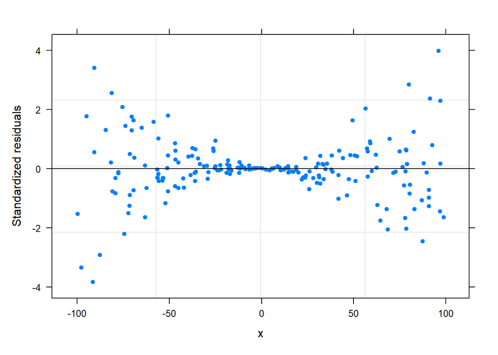

```r
plot(fit0, resid(., type = "p") ~ x, abline = 0, pch=20)
```

De la figura anterior vemos claramente una forma de “nudo”, abierto a izquierda y abierto a la derecha, esto es un indicio de que se debe modelar la varianza $\sigma^2_y$.

El siguiente modelo permite que la varianza $\sigma^2_y$ sea función de $X$ usando una estructura `varPower`.

```r
fit1 <- lme(y ~ x, random = ~ 1 | grupo, weights=varPower(form=~ x), data=datos) #Es necesario indicar el parámetro form a la hora de utilizar la estructura varPower
```

A continuación repetimos la misma figura de residuales anterior. De esta figura logramos ver que se eliminó el patrón de “nudo” observado antes.

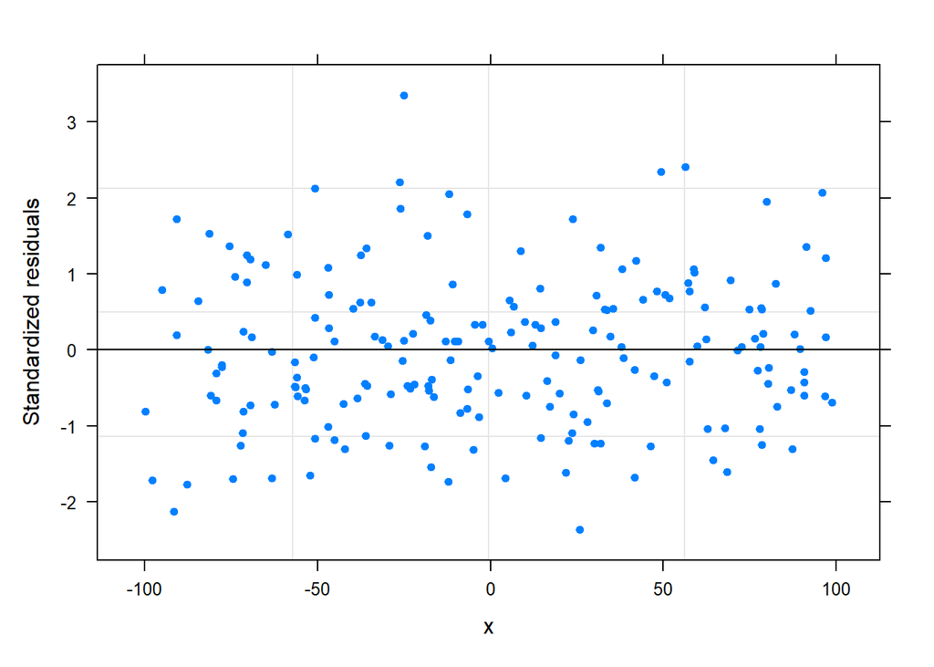

```r
plot(fit1, resid(., type = "p") ~ x, abline = 0, pch=20)
```

La función `summary` se puede usar sobre el objeto `fit1` para obtener una tabla de resumen, a continuación se ilustra el uso y la salida de `summary`.

```r
summary(fit1)
```

```
## Linear mixed-effects model fit by REML
##   Data: datos
##        AIC      BIC    logLik
##   3243.695 3260.136 -1616.848
##
## Random effects:
##  Formula: ~1 | grupo
##         (Intercept) Residual
## StdDev:    12.36973 3.428297
##
## Variance function:
##  Structure: Power of variance covariate
##  Formula: ~x
##  Parameter estimates:
##    power
## 1.523856
## Fixed effects:  y ~ x
##                 Value Std.Error  DF    t-value p-value
## (Intercept)  4.906539  6.231888 179  0.7873278  0.4321
## x           -0.614254  1.317635 179 -0.4661795  0.6417
##  Correlation:
##   (Intr)
## x 0.083
##
## Standardized Within-Group Residuals:
##         Min          Q1         Med          Q3         Max
## -2.37122577 -0.66262664 -0.01746898  0.58665545  3.35537820
##
## Number of Observations: 200
## Number of Groups: 20
```

Según el resultado anterior:

$\hat{\boldsymbol{\Theta}}=(\hat{\beta}_0=4.90, \hat{\beta}_1=-0.61, \hat{\sigma}=3.43, \hat{\delta}=1.52, \hat{\sigma}_{b0}=12.37)^\top$ Dónde rápidamente se concluye que el valor estimado $\hat{\delta}$ se acerca al valor real y que los los valores estimados $\hat{\beta}_0$ y $\hat{\beta}_1$ no se acercan a los valores reales.

```r
anova.lme(fit0, fit1)
```

```
##      Model df      AIC      BIC    logLik   Test  L.Ratio p-value
## fit0     1  4 3551.293 3564.446 -1771.646
## fit1     2  5 3243.695 3260.136 -1616.848 1 vs 2 309.5975  <.0001
```